# MATH1324 Assignment 2

Supermarket Price Wars

## Group/Individual Details

- Thomas Le s3491287

## Executive Statement

The aim of this investigation is to determine whether Woolworths or Coles have better pricing over the other. The products were sampled through simple random sampling (SRS). A numbered list of products was made on excel and using a random number generator, 33 items were randomly selected based on the random number given. As per the central limit theorem a size greater than 30 was sufficient to sample considering time and resource constraints. The products were matched via each website to ensure the same type of product, brand and weight or volume were consistent. Prices appeared to be quite small, with items being mostly under 13AUD. Any outliers would have skewed the mean, therefore items were capped at 15AUD.

A paired t-test was used to find if there were any significant difference between the mean prices of each supermarket. It was found that there was significant difference and that Coles was cheaper to shop at on average.

## Load Packages and Data

```r
library(ggplot2)
library(readxl)
library(dplyr)
Prices <- read_xlsx("Book1.xlsx")
Prices2 <- read_xlsx("Book2.xlsx")
```

## Summary Statistics

A sample of 33 products were used to compare the summary statistics. It appears the mean of Woolworths is slightly greater with a mean of 5.22AUD vs Coles; 4.70AUD.

```r
Prices %>% group_by(Store) %>% summarise(Min = min(Prices, na.rm = TRUE),
                                          Q1 = quantile(Prices,probs = .25,na.rm = TRUE),
                                         Median = median(Prices, na.rm = TRUE),
                                         Q3 = quantile(Prices,probs = .75,na.rm = TRUE),
                                         Max = max(Prices,na.rm = TRUE),
                                         Mean = mean(Prices, na.rm = TRUE),
                                         SD = sd(Prices, na.rm = TRUE),
                                         n = n(),
                                         Missing = sum(is.na(Prices)))
```

| Store | Min | Q1 | Median | Q3 | Max | Mean | SD | n | Missing |
| --- | --- | --- | --- | --- | --- | --- | --- | --- | --- |
| Coles | 1.47 | 2.50 | 4.25 | 6.35 | 13 | 4.706364 | 2.660035 | 33 | 0 |
| Woolworths | 1.15 | 2.95 | 5.10 | 7.00 | 13 | 5.226970 | 2.866303 | 33 | 0 |

Visual Comparison:

The boxplot showed that the IQR of Woolworth is slightly larger. There is an ‘outlier’ for Coles, but the outlier and the max price are of the same product from both supermarkets. It is shown as an ‘outlier’ for Coles because the prices overall from Coles appear to be lower and therefore products of 13AUD was seen as an outlier.

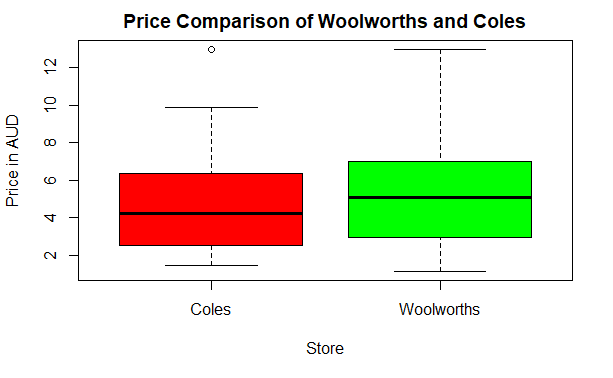

```r
Prices %>% group_by(Store) %>% boxplot(Prices ~ Store, data = .,
                                      main = "Price Comparison of Woolworths and Coles",
                                      ylab = "Price in AUD",
                                      col = c("red", "green"))
```

Price Variation/Difference:

Of the 33 sample products, We can see from the line plot more of the price movement is moving down as it moves across to Coles. 15 products had the same price.

- A line plot was used as the data set was not large.

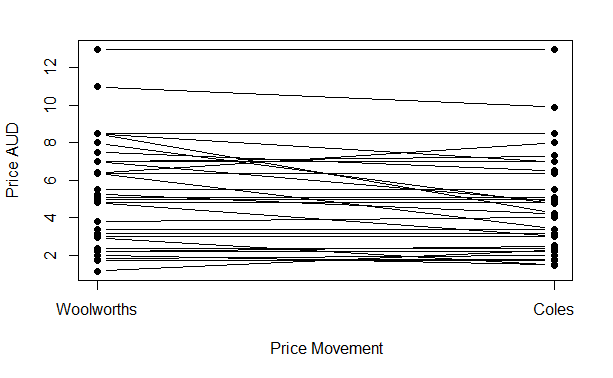

```r
matplot(t(data.frame(Prices2$Woolworth, Prices2$Coles)),
  type = "b",
  pch = 19,
  col = 1,
  lty = 1,
  xlab = " Price Movement",
  ylab = "Price AUD",
  xaxt = "n")
axis(1, at = 1:2, labels = c("Woolworths", "Coles"))
```

## Hypothesis Test

The null hypothesis is that the product prices between Woolworths and Coles have no signficance difference.

- H0 : μΔ = 0
- HA : μΔ ≠ 0 HA : μΔ < 0 HA : μΔ > 0

A paired sample t-test was performed to compare the mean prices of Woolworths and Coles. A 95% Confidence Interval was used and a significance level of p<0.05. A paired t-test was used as we are comparing the same product from two different population (Woolworths and Coles).

It was assumed that the depend variable should be approximately follow a normal distribution, as per the central limit theorem (n>30). Each product was different from each other, and the dependent variable (price) does not contain outliers.

```r
t.test(Prices2$Woolworth, Prices2$Coles, paired = TRUE, alternative = "two.sided")
```

```
    Paired t-test

data:  Prices2$Woolworth and Prices2$Coles
t = 2.4296, df = 32, p-value = 0.02091
alternative hypothesis: true difference in means is not equal to 0
95 percent confidence interval:
 0.08413568 0.95707644
sample estimates:
mean of the differences
              0.5206061
```

## Discussion

From the investigation it was concluded that on average the prices at Coles were lower than Woolworths.

Strengths:

- Convenience to online access to data for the prices of both supermarkets

Limitations:

- Unable to capture the whole population of both supermarkets
- Smaller data set was used due to time constraints and working individually.
- Some of the products were on specials or discounts from both supermarkets, but this was a more realistic approach as there are always different sales and discounts occuring from both supermarkets on a broad range of products.

Sampling could have been improved due to time and resource constraints. The investigation overall concluded that at this time, Coles offers better value for shoppers.